# Homework 9

4/21/2025

Kaustubh Duddala

[Github](https://github.com/kaustubhduddala/StatisticsAndDataScience/tree/main/SDS%20315/Homework%209)

## Question 1

#### A

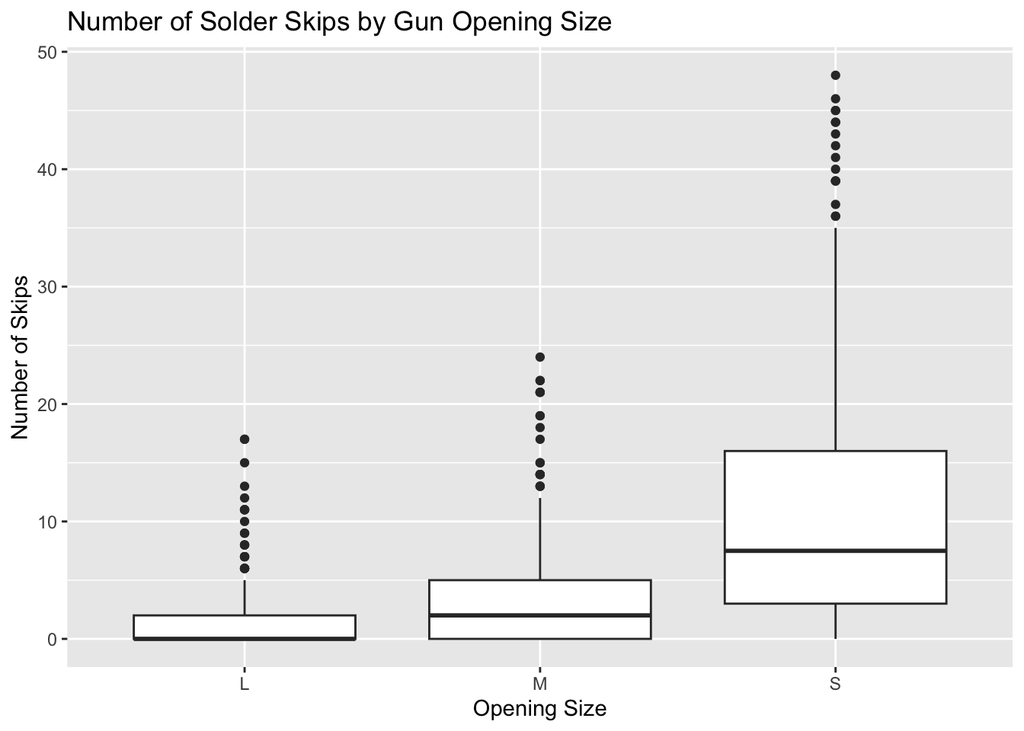

This boxplot shows the distribution of solder skips across different opening sizes. `Large` openings exhibit the lowest median number of skips, followed by `Medium`, while `Small` openings have the highest median.

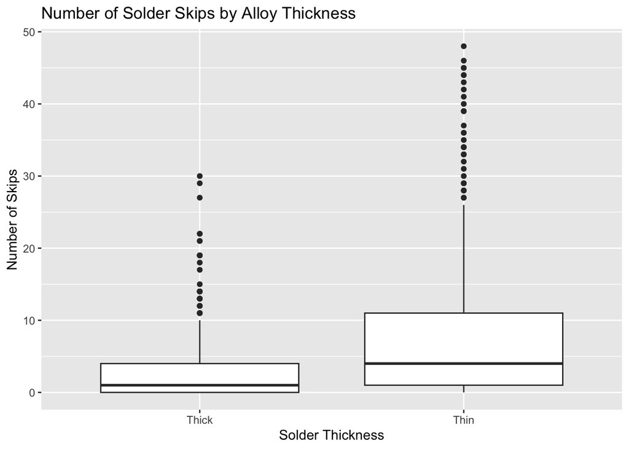

This boxplot displays the number of solder skips based on alloy thickness. Alloys with `Thin` thickness show a significantly higher median number of skips compared to `Thick` alloys, and also exhibit more frequent and more extreme outliers

#### B

```
## # A tibble: 6 × 7
##   term                  estimate std_error statistic p_value lower_ci upper_ci
##   <chr>                    <dbl>     <dbl>     <dbl>   <dbl>    <dbl>    <dbl>
## 1 intercept                0.393     0.52      0.756   0.45    -0.628     1.42
## 2 Opening: M               2.41      0.736     3.27    0.001    0.962     3.85
## 3 Opening: S               5.13      0.736     6.97    0        3.68      6.57
## 4 Solder: Thin             2.28      0.736     3.10    0.002    0.836     3.72
## 5 Opening: M:SolderThin   -0.74      1.04     -0.711   0.477   -2.78      1.30
## 6 Opening: S:SolderThin    9.65      1.04      9.28    0        7.61     11.7
```

Table with estimates and 95% confidence intervals.

#### C

The estimated average number of solder skips from the baseline condition (large opening, thick solder) is 0.393 skips.

The main effect estimate for Medium opening (compared to the Large opening baseline) is 2.407 skips, which is the estimated increase in average skips when switching from large to medium opening when using Thick solder.

The main effect estimate for Small opening (compared to the Large opening baseline) is 5.127 skips, which is the estimated increase in average skips when switching from large to small opening when using Thick solder.

The main effect estimate for Thin solder compared to the baseline Thick solder is 2.28 skips, which is the estimated increase in average skips when switching from Thick to Thin solder.

The interaction effect estimate for the Medium opening and Thin Solder is -0.74 skips, which indicates that a combination of Medium opening and Thin solder results in an average number of skips that is 0.74 lower than simply adding individual main effects of medium opening and thin solder effects.

The interaction effect estimate for the Small opening and Thin solder is 9.653 skips, which indicates that a combination of Small opening and Thin solder results in an average number of skips that is 9.653 higher than simply adding the individual main effects of Small opening and Thin solder together.

#### D

6 combinations of solder type and opening size:

Large Opening, Thick Solder: 0.393 skips

Large Opening, Thin Solder: 2.673 skips

Medium Opening, Thick Solder: 2.8 skips

Medium Opening, Thin Solder: 4.34 skips

Small Opening, Thick Solder: 5.52 skips

Small Opening, Thin Solder: 17.453 skips

Based on these combinations, I would recommend having the Large Opening size and the Thick Solder. This gives the lowest average number of skips in the process, of 0.393 as an average.

## Question 2

#### A

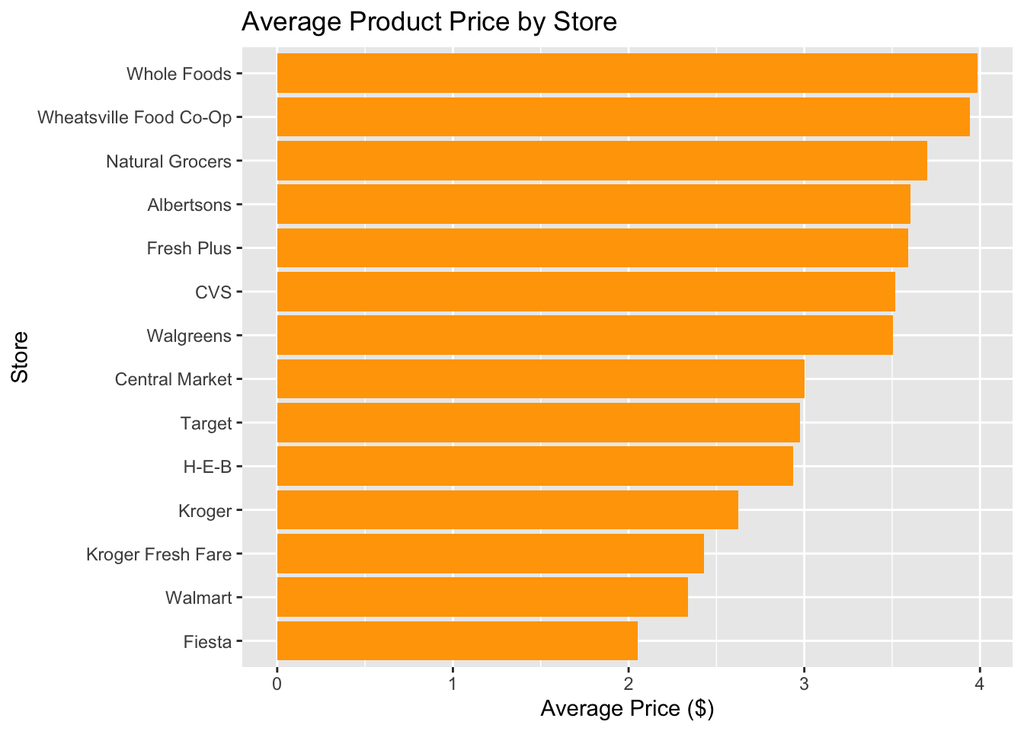

The bar graph displays the average price of different products at each store. Whole Foods has the highest average price, while Fiesta has the lowest.

#### B

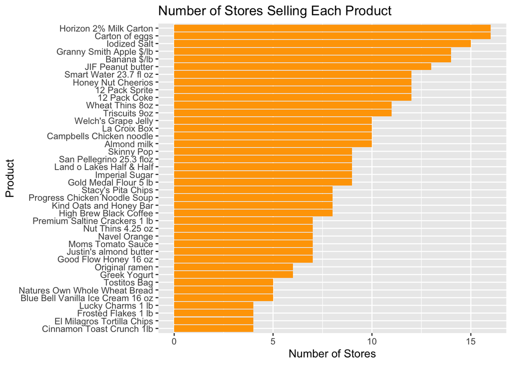

This graph illustrates product availability across all 16 stores. Horizon 2% Milk and eggs are stocked at every location, while some cereals and tortilla chips are among the least available.

#### C

Compared with ordinary grocery stores (like Albertsons, HEB, or Krogers), convenience stores charge somewhere between 0.92 and 0.41 dollars more for the same product (baseline in this model was Convenience stores).

#### D

Based on the regression model, the two stores with the lowest prices when comparing the same product are Walmart and Kroger Fresh Fare. The two stores with the highest prices when comparing the same product are Wheatsville Food Co-Op and Whole Foods.

#### E

Central Market does charge a bit more per product than HEB does, about 0.07 dollars more. However, in the grand context, when looking at all the stores in the dataset the store effects range from 1.36 dollars more for the same product from the lowest amount when comparing the most and least expensive stores, so 0.07 dollars of difference isn’t that huge in context.

#### F

Based on the negative sign of the income_10k coefficient, consumers in poorer ZIP codes seem to pay more for the same product, on average, as the sign indicates the higher the income, the less people pay.

A one-standard deviation increase in the income of a ZIP code seems to be associated with a -0.03 standard-deviation change in the price that consumers in that ZIP code expect to pay for the same product.

## Question 3

#### D

False. Although including income in the model reduces the coefficient for minority (from `0.014` in model_D1 to `0.01` in model_D2), the minority variable remains statistically significant, with a p-value of `0.002` and a 95% confidence interval of (`0.004`, `0.015`), which does not include zero. Therefore, income does not fully account for the observed association. A more accurate interpretation is that income partially explains the relationship, but the association between minority percentage and FAIR policy adoption remains statistically significant.

#### E

True. Model_E shows that the minority coefficient remains positive and statistically significant (`0.008`) even after accounting for fire risk, income, and housing age. The 95% confidence interval is (`0.003`, `0.014`), and the p-value is `0.006`, suggesting a persistent positive relationship between minority percentage and FAIR policies across ZIP codes after adjusting for these factors.